# Saxon State Election 2024: Sample and Descriptives

The PTV item of each party.

```r
ptv_col_by_party_saxony <- c(
  "AfD"         = "ptv_afd",
  "BSW"         = "ptv_bsw",
  "CDU"         = "ptv_cdu",
  "FDP"         = "ptv_fdp",
  "Greens"      = "ptv_gruene",
  "Left"        = "ptv_linke",
  "SPD"         = "ptv_spd",
  "Free Voters" = "ptv_fw"
)
```

```r
load("data/processed/data_saxony.rdata")
load("data/processed/data_saxony_long.rdata")
```

# Data

## Exclusion of Satisficers

Respondents who allocated 100% to one party are excluded as satisficers (paper section Data). For each respondent, the number of sliders set to 100 is counted, and respondents with one such slider are flagged as `excluded`. Two data sets are kept for every later step:

- `data_saxony_main`: the analytic sample, without the excluded respondents,
- `data_saxony_noexcl`: all respondents, for the robustness checks without exclusions.

The same split is made for the long data (one row per respondent and party).

```r
list_votes_exp_vars_saxony <- c(
  "list_votes_exp_cdu", "list_votes_exp_afd", "list_votes_exp_linke",
  "list_votes_exp_gruene", "list_votes_exp_spd", "list_votes_exp_fdp",
  "list_votes_exp_bsw", "list_votes_exp_fw", "list_votes_exp_other"
)

data_saxony_noexcl <- data_saxony %>%
  mutate(
    n_100 = rowSums(across(all_of(list_votes_exp_vars_saxony)) == 100),
    excluded = n_100 == 1,
    excl_reason = if_else(excluded, "100 for one party", "included")
  ) %>%
  select(-n_100)

data_saxony_long_noexcl <- data_saxony_long %>%
  left_join(data_saxony_noexcl %>% select(ResponseId, excluded, excl_reason, zs_int), by = "ResponseId")

data_saxony_main <- data_saxony_noexcl %>% filter(!excluded)
data_saxony_long_main <- data_saxony_long_noexcl %>% filter(!excluded)
```

Recruited, excluded and analytic sample.

```r
data_saxony_noexcl %>% count(excl_reason)
```

```
# A tibble: 2 × 2
  excl_reason           n
  <chr>             <int>
1 100 for one party    97
2 included           5562
```

```r
data_saxony_noexcl %>%
  summarize(recruited = n(), analytic = sum(!excluded), excluded = sum(excluded))
```

```
# A tibble: 1 × 3
  recruited analytic excluded
      <int>    <int>    <int>
1      5659     5562       97
```

```r
rm(data_saxony, data_saxony_long)
```

## Benchmarks for the Sample Composition

The sample composition table (Table B.4) compares the sample with benchmarks from official statistics. This section builds one benchmark share per category of the table.

Eligible voters by gender and age, from the representative electoral statistics of the 2024 state election (Statistisches Landesamt Sachsen). Age groups are combined into the age groups of the survey, and men include diverse and unspecified voters, as Men* in the survey.

```r
df_saxony_rep <- read_excel(
  "data/input/benchmark/statistik-sachsen_bVII2-3_saechsischer-landtag-repraesentative-wahlstatistik.xlsx",
  sheet = 5, skip = 3
) %>%
  set_names(c(
    "gender", "age_group", "wahlberechtigte_insgesamt",
    "Wahlberechtigte \r\nmit Wahlschein", "Wahlberechtigte \r\nohne Wahlschein",
    "Wähler/-innen\r\n(ohne Briefwahl)", "Nichtwähler/\r\n-innen"
  ))

df_gender_age_saxony <- df_saxony_rep %>%
  filter(gender != "Insgesamt", age_group != "zusammen") %>%
  mutate(
    age_group = case_when(
      age_group %in% c("18 bis unter 21", "21 bis unter 25", "25 bis unter 30") ~ "18-29",
      age_group %in% c("30 bis unter 35", "35 bis unter 40") ~ "30-39",
      age_group %in% c("40 bis unter 45", "45 bis unter 50") ~ "40-49",
      age_group == "50 bis unter 60" ~ "50-59",
      age_group %in% c("60 bis unter 70", "70 und älter") ~ "60+",
      TRUE ~ NA_character_
    ),
    gender = case_when(
      gender == "Männer, divers, o. A." ~ "Men",
      gender == "Frauen" ~ "Women",
      TRUE ~ NA_character_
    ),
    Wahlberechtigte = as.numeric(wahlberechtigte_insgesamt) * 1000
  ) %>%
  filter(!is.na(age_group), !is.na(gender)) %>%
  group_by(age_group, gender) %>%
  summarize(Wahlberechtigte = sum(Wahlberechtigte, na.rm = TRUE), .groups = "drop")

# Totals by gender over all age groups
df_gender_age_saxony <- df_gender_age_saxony %>%
  bind_rows(
    df_gender_age_saxony %>%
      group_by(gender) %>%
      summarize(Wahlberechtigte = sum(Wahlberechtigte), .groups = "drop") %>%
      mutate(age_group = "Insgesamt")
  )

df_age_saxony <- df_gender_age_saxony %>%
  filter(age_group != "Insgesamt") %>%
  pivot_wider(names_from = gender, values_from = Wahlberechtigte) %>%
  mutate(
    eligible_age_group = Men + Women,
    eligible_total     = sum(eligible_age_group),
    benchmark          = eligible_age_group / eligible_total
  ) %>%
  select(age_group, benchmark)

df_gender_saxony <- df_gender_age_saxony %>%
  filter(age_group == "Insgesamt") %>%
  select(-age_group) %>%
  rename(eligible_gender_group = Wahlberechtigte) %>%
  mutate(
    eligible_total = sum(eligible_gender_group),
    benchmark      = eligible_gender_group / eligible_total
  ) %>%
  select(gender, benchmark)
```

Benchmark of education: the school-leaving qualification of the Saxon population (Mikrozensus, GENESIS table 12211-1100). The qualifications are grouped into the three levels of the survey (Low, Medium, High) plus “Still in School”. The census reports thousands of persons.

```r
df_census_saxony_raw <- read_excel("data/input/benchmark/12211-1100_de.xlsx") %>%
  set_names(c(
    "gender", "age_group",
    "Noch in schulischer Ausbildung", "Haupt- (Volks-)schulabschluss",
    "Abschluss der polytechnischen Oberschule", "Realschule oder gleichwertiger Abschluss",
    "Fachhochschul- oder Hochschulreife", "Ohne Angabe zur Art des Abschlusses",
    "Ohne allgemeinen Schulabschluss", "Insgesamt"
  ))

df_educ_saxony <- df_census_saxony_raw %>%
  drop_na("age_group") %>%
  fill(gender, .direction = "down") %>%
  filter(gender == "Insgesamt", age_group == "Insgesamt") %>%
  select(-age_group, gender) %>%
  mutate(across(.cols = everything(), .fns = ~ as.numeric(.)),
    Low = `Haupt- (Volks-)schulabschluss` + `Ohne allgemeinen Schulabschluss`,
    Medium = `Realschule oder gleichwertiger Abschluss` + `Abschluss der polytechnischen Oberschule`,
    High = `Fachhochschul- oder Hochschulreife`,
    `Still in School` = `Noch in schulischer Ausbildung`,
    census_total = Insgesamt * 1000
  ) %>%
  select(Low, Medium, High, `Still in School`, census_total) %>%
  pivot_longer(cols = Low:`Still in School`, names_to = "education_eng", values_to = "pop_clean") %>%
  mutate(pop_clean = pop_clean * 1000, benchmark = pop_clean / census_total) %>%
  select(education_eng, benchmark)
```

Benchmark of the vote intention: the election result.

```r
zs_benchmark_saxony <- data_saxony_long_main %>%
  distinct(party, list_votes_result) %>%
  mutate(
    party = if_else(party == "Others", "Other", party),
    benchmark = list_votes_result / 100
  ) %>%
  select(list_vote_int_eng = party, benchmark)
```

Benchmark of the turnout intention: the turnout of the 2024 state election (74.4%).

```r
turnout_benchmark_saxony <- tibble(turnout_int_eng = "Yes", benchmark = 0.744)
```

## Response Times

The H1 model controls for each respondent’s general speed in the survey. This baseline speed is the log of the mean response time of five filler items (birth year, vote intention, eligibility, turnout intention, political interest). Item times more than two standard deviations from the item mean are left out of this mean.

Response times of the expectation item more than two standard deviations above the mean are outliers and removed from the H1 models (paper section Modeling). Since the lower cutoff (mean - 2 SD) is negative, no response time is removed at the bottom. The output checks this (`TRUE` = lower cutoff below zero).

```r
data_saxony_time_main <- add_baseline_speed(data_saxony_main) # helper
data_saxony_time_noexcl <- add_baseline_speed(data_saxony_noexcl) # helper

t_mean_saxony <- mean(data_saxony_time_main$t_list_votes_exp_Page_Submit, na.rm = TRUE)
t_threshold_upper_saxony <- compute_time_cutoff(data_saxony_time_main$t_list_votes_exp_Page_Submit) # helper

# No response lies more than 2 SD below the mean
data_saxony_time_main %>%
  summarize(lower_cutoff_below_zero = mean(t_list_votes_exp_Page_Submit) - 2 * sd(t_list_votes_exp_Page_Submit) < 0)
```

```
# A tibble: 1 × 1
  lower_cutoff_below_zero
  <lgl>
1 TRUE
```

```r
data_saxony_time_main <- data_saxony_time_main %>%
  mutate(t_outlier = t_list_votes_exp_Page_Submit > t_threshold_upper_saxony)

data_saxony_time_main_nooutliers <- data_saxony_time_main %>% filter(!t_outlier)
```

Response times before outlier removal (paper section Modeling and note of Figure B.1).

```r
data_saxony_time_main %>%
  summarize(
    n = n(),
    min = min(t_list_votes_exp_Page_Submit),
    max = max(t_list_votes_exp_Page_Submit),
    mean = mean(t_list_votes_exp_Page_Submit),
    sd = sd(t_list_votes_exp_Page_Submit),
    cutoff = t_threshold_upper_saxony,
    n_removed = sum(t_outlier),
    n_after_removal = sum(!t_outlier)
  ) %>%
  print_values(digits = 1) # helper
```

```
    n min     max  mean    sd cutoff n_removed n_after_removal
 5562 3.8 23988.8 110.1 330.1  770.3         8            5554
```

## Preferred Party (PTV, Vote Intention, Party Identification)

H3 compares the forecast error for the respondent’s preferred party with that for the other parties. The preferred party is the party with the highest propensity to vote (PTV). Respondents who give the highest PTV to more than one party have no clearly preferred party and are removed (paper section Modeling).

Alternative measures (robustness checks):

- PTV dummy, but allowing ties (all parties with the highest PTV count as preferred),
- vote intention,
- party identification,
- the PTV score of each party (1-11) instead of a dummy.

First, the party (or the tied parties, comma-separated) with the highest PTV of each respondent.

```r
data_saxony_ptvtop_noexcl <- add_ptv_top(data_saxony_noexcl, ptv_col_by_party_saxony) # helper
data_saxony_ptvtop_main <- data_saxony_ptvtop_noexcl %>% filter(!excluded)
```

Respondents with no PTV at all, with a tied highest PTV and with a clearly preferred party.

```r
data_saxony_ptvtop_main %>%
  summarize(
    no_ptv = nrow(data_saxony_main) - n(),
    tied = sum(str_detect(preferred_party, ",")),
    clear = sum(!str_detect(preferred_party, ","))
  )
```

```
# A tibble: 1 × 3
  no_ptv  tied clear
   <int> <int> <int>
1      8   889  4665
```

The clearly preferred party (PTV, without ties) is added to the long data. Respondents with tied PTVs get `NA`.

```r
data_saxony_long_noexcl <- data_saxony_long_noexcl %>%
  left_join(
    data_saxony_ptvtop_noexcl %>%
      filter(!str_detect(preferred_party, ",")) %>%
      select(ResponseId, preferred_party),
    by = "ResponseId"
  )
data_saxony_long_main <- data_saxony_long_noexcl %>% filter(!excluded)
```

For every measure, a dummy in the long data: 1 if the party of the row is the respondent’s preferred party, 0 if not.

*Others* is left out, since it is no party one can prefer. The PTV score of the party of each row is added as well.

```r
pref_long_saxony <- create_pref_long_data(
  data_saxony_long_noexcl, data_saxony_ptvtop_noexcl, # helper
  ptv_col_by_party_saxony, parties_8_saxony
)
data_saxony_long_pref_main <- pref_long_saxony %>%
  filter(!excluded) %>%
  select(-excluded)
```

The model data of the H3 models, one data set per measure, for the main sample and without exclusions. Each keeps the rows with a non-missing value on its measure. The table shows the number of respondents and rows (respondent × party) per measure in the main sample.

```r
subsets_saxony_main <- create_pref_model_data(data_saxony_long_pref_main) # helper
data_saxony_ptv_main <- subsets_saxony_main$ptv
data_saxony_vi_main <- subsets_saxony_main$vi
data_saxony_pid_main <- subsets_saxony_main$pid
data_saxony_ptvscore_main <- subsets_saxony_main$ptvscore
data_saxony_ptvties_main <- subsets_saxony_main$ptvties

subsets_saxony_noexcl <- create_pref_model_data(pref_long_saxony %>% select(-excluded)) # helper
data_saxony_ptv_noexcl <- subsets_saxony_noexcl$ptv
data_saxony_vi_noexcl <- subsets_saxony_noexcl$vi
data_saxony_pid_noexcl <- subsets_saxony_noexcl$pid
data_saxony_ptvscore_noexcl <- subsets_saxony_noexcl$ptvscore
data_saxony_ptvties_noexcl <- subsets_saxony_noexcl$ptvties

subsets_saxony_main %>%
  map_dfr(~ summarize(.x, respondents = n_distinct(ResponseId), rows = n()), .id = "measure")
```

```
# A tibble: 5 × 3
  measure  respondents  rows
  <chr>          <int> <int>
1 ptv             4665 37187
2 ptvties         5554 44432
3 vi              5269 42152
4 pid             4707 37656
5 ptvscore        5554 44274
```

For the descriptives of the preferred party (PTV): one row per respondent, the row of the preferred party.

```r
data_saxony_prefparty_ptv_main <- create_pref_party_data(data_saxony_long_main, "preferred_party", parties_8_saxony) # helper

rm(pref_long_saxony, subsets_saxony_main, subsets_saxony_noexcl, data_saxony_ptvtop_noexcl)
```

# Sample

Size of the analytic sample and the experimental groups (paper section Data).

```r
data_saxony_main %>% count(treatment)
```

```
# A tibble: 2 × 2
  treatment           n
  <fct>           <int>
1 Control          2824
2 Treatment (500)  2738
```

Field period by recruitment channel.

```r
data_saxony_main %>%
  group_by(recruit) %>%
  summarize(n = n(), first_day = min(interview_date), last_day = max(interview_date))
```

```
# A tibble: 2 × 4
  recruit     n first_day  last_day
  <chr>   <int> <date>     <date>
1 OAP      2161 2024-07-26 2024-08-30
2 SM       3401 2024-07-26 2024-08-24
```

Commitment pledge not to consult outside sources (%).

```r
data_saxony_noexcl %>%
  count(pledge_expectations) %>%
  mutate(pct = 100 * n / sum(n)) %>%
  print_values() # helper
```

```
              pledge_expectations    n   pct
 Nein, ich bin nicht dazu bereit.   44  0.78
              Ja, ich bin bereit. 5571 98.44
                             <NA>   44  0.78
```

## Sample Composition (Table B.4)

Sample before exclusions compared with the electorate (left) and change through the exclusions (right), also by recruitment channel. First, the benchmark of every category of the table.

```r
df_benchmark_raw_saxony <- bind_rows(
  compute_group_shares(data_saxony_main, "age_group", "Age Group", election = "saxony") %>% # helper
    left_join(df_age_saxony %>% rename(category = age_group), by = "category"),
  compute_group_shares(data_saxony_main, "gender_eng2", "Gender", election = "saxony") %>% # helper
    left_join(df_gender_saxony %>% rename(category = gender), by = "category") %>%
    mutate(category = if_else(category == "Men", "Men*", category)),
  compute_group_shares(data_saxony_main, "education_eng", "Education", election = "saxony") %>% # helper
    left_join(df_educ_saxony %>% rename(category = education_eng), by = "category"),
  compute_group_shares(data_saxony_main, "turnout_int_eng", "Turnout Intention", election = "saxony") %>% # helper
    filter(category == "Yes") %>%
    left_join(turnout_benchmark_saxony %>% rename(category = turnout_int_eng), by = "category"),
  compute_group_shares(data_saxony_main, "list_vote_int_eng", "Vote Intention", election = "saxony") %>% # helper
    left_join(zs_benchmark_saxony %>% rename(category = list_vote_int_eng), by = "category")
)

df_benchmark_raw_saxony %>%
  transmute(variable, category, benchmark_pct = 100 * benchmark) %>%
  print_values(digits = 1) # helper
```

```
          variable        category benchmark_pct
         Age Group           18-29          10.9
         Age Group           30-39          12.4
         Age Group           40-49          14.8
         Age Group           50-59          16.1
         Age Group             60+          45.8
            Gender            Men*          48.1
            Gender           Women          51.9
         Education             Low          15.6
         Education          Medium          51.4
         Education            High          29.8
         Education Still in School           3.2
 Turnout Intention             Yes          74.4
    Vote Intention             AfD          30.6
    Vote Intention          Greens           5.1
    Vote Intention             BSW          11.8
    Vote Intention             CDU          31.9
    Vote Intention             FDP           0.9
    Vote Intention            Left           4.5
    Vote Intention             SPD           7.3
    Vote Intention     Free Voters           2.3
    Vote Intention           Other           5.6
```

The table: shares in the sample before exclusions with the difference to the benchmark, and shares in the main sample with the change through the exclusions, overall, by recruitment channel and by experimental group. It is written to LaTeX and shown here as HTML.

```r
balance_specs_saxony <- tribble(
  ~var,                ~label,
  "age_group",         "Age Group",
  "gender_eng2",       "Gender",
  "education_eng",     "Education",
  "turnout_int_eng",   "Turnout Intention",
  "list_vote_int_eng", "Vote Intention"
)

balance_groups_saxony <- c(full = "All", oap = "OAP", sm = "SM", control = "C", t500 = "T(500)")

df_balance_saxony <- compute_balance_shares_recruit_saxony(data_saxony_noexcl, balance_specs_saxony) %>% # helper
  rename_with(~ sub("^share_", "before_", .x), starts_with("share_")) %>%
  full_join(
    compute_balance_shares_recruit_saxony(data_saxony_main, balance_specs_saxony) %>% # helper
      rename_with(~ sub("^share_", "main_", .x), starts_with("share_")),
    by = c("variable", "category")
  ) %>%
  mutate(across(starts_with(c("before_", "main_")), ~ coalesce(.x, 0))) %>%
  left_join(df_benchmark_raw_saxony %>% select(variable, category, benchmark), by = c("variable", "category"))

note_balance_saxony <- paste0(
  "Note: Cells show the share of respondents (\\%) before exclusions (left) and in the main ",
  "sample (right), overall, by recruitment channel (OAP = online access panel, SM = social media), ",
  "and by experimental group. In the main sample, ",
  format(nrow(data_saxony_noexcl) - nrow(data_saxony_main), big.mark = ","),
  " respondents who allocated 100\\% to one party are excluded. ",
  "For the overall sample, the difference to a benchmark is shown in percentage points in ",
  "parentheses. For the main sample, the difference to the overall sample before exclusions ",
  "is shown. Darker shading indicates larger absolute differences (scale up to 20 ",
  "percentage points on the left and up to 5 percentage points on the right). ",
  "Benchmarks are the eligible voting population for age and gender ",
  "\\parencite{statistischeslandesamtdesfreistaatessachsenRepraesentativeWahlstatistik2024}, ",
  "the overall population for education ",
  "\\parencite{statistischesbundesamtdestatisCode122111100Tabelle2026}, election results ",
  "for vote intention, and actual turnout for turnout intention ",
  "\\parencite{statistischeslandesamtdesfreistaatessachsenWahlergebnisse2024}. ",
  "Men* includes men and diverse respondents."
)

# Ten sample columns, hence a smaller font than in Table B.3
write_balance_table( # helper
  data = df_balance_saxony,
  groups = balance_groups_saxony,
  n_before = count_by_group(data_saxony_noexcl, election = "saxony"), # helper
  n_main = count_by_group(data_saxony_main, election = "saxony"), # helper
  caption = "Demographic Composition of the Saxon Sample (Before and After Exclusions)",
  label = "tab:balance_table_saxony",
  note = note_balance_saxony,
  file = "output/tables/table_B4_balance_demographics_saxony.tex",
  font_px = 9
)
```

Demographic Composition of the Saxon Sample (Before and After Exclusions)

|  | Bench- mark | Before Exclusions (Difference to Benchmark) All n = 5,659 | Before Exclusions (Difference to Benchmark) OAP n = 2,223 | Before Exclusions (Difference to Benchmark) SM n = 3,436 | Before Exclusions (Difference to Benchmark) C n = 2,889 | Before Exclusions (Difference to Benchmark) T(500) n = 2,770 | Main Sample (Difference to Before Exclusions) All n = 5,562 (-97) | Main Sample (Difference to Before Exclusions) OAP n = 2,161 (-62) | Main Sample (Difference to Before Exclusions) SM n = 3,401 (-35) | Main Sample (Difference to Before Exclusions) C n = 2,824 (-65) | Main Sample (Difference to Before Exclusions) T(500) n = 2,738 (-32) |
| --- | --- | --- | --- | --- | --- | --- | --- | --- | --- | --- | --- |
| Age Group |  |  |  |  |  |  |  |  |  |  |  |
| 18-29 | 10.9 | 11.3 (+0.4) | 15.2 (+4.3) | 8.8 (-2.1) | 11.3 (+0.4) | 11.3 (+0.4) | 11.3 (0.0) | 15.1 (0.0) | 8.9 (0.0) | 11.3 (0.0) | 11.3 (-0.1) |
| 30-39 | 12.4 | 17.6 (+5.2) | 21.1 (+8.6) | 15.4 (+3.0) | 18.0 (+5.5) | 17.3 (+4.9) | 17.6 (0.0) | 21.0 (-0.1) | 15.5 (+0.1) | 18.0 (0.0) | 17.3 (0.0) |
| 40-49 | 14.8 | 22.4 (+7.6) | 19.0 (+4.1) | 24.7 (+9.8) | 22.6 (+7.7) | 22.3 (+7.5) | 22.5 (0.0) | 18.9 (-0.1) | 24.8 (+0.1) | 22.5 (-0.1) | 22.5 (+0.2) |
| 50-59 | 16.1 | 23.2 (+7.1) | 22.4 (+6.3) | 23.7 (+7.7) | 23.2 (+7.2) | 23.2 (+7.1) | 23.2 (0.0) | 22.4 (0.0) | 23.7 (0.0) | 23.3 (0.0) | 23.1 (-0.1) |
| 60+ | 45.8 | 25.4 (-20.4) | 22.4 (-23.3) | 27.3 (-18.5) | 24.9 (-20.8) | 25.9 (-19.9) | 25.4 (0.0) | 22.7 (+0.2) | 27.1 (-0.2) | 24.9 (0.0) | 25.9 (0.0) |
| Gender |  |  |  |  |  |  |  |  |  |  |  |
| Men* | 48.1 | 59.3 (+11.2) | 49.2 (+1.1) | 65.9 (+17.8) | 59.7 (+11.6) | 58.9 (+10.8) | 59.4 (+0.1) | 49.3 (+0.1) | 65.9 (0.0) | 59.7 (0.0) | 59.1 (+0.2) |
| Women | 51.9 | 40.7 (-11.2) | 50.8 (-1.1) | 34.1 (-17.8) | 40.3 (-11.6) | 41.1 (-10.8) | 40.6 (-0.1) | 50.7 (-0.1) | 34.1 (0.0) | 40.3 (0.0) | 40.9 (-0.2) |
| Education |  |  |  |  |  |  |  |  |  |  |  |
| Low | 15.6 | 4.9 (-10.7) | 8.6 (-6.9) | 2.5 (-13.1) | 5.1 (-10.5) | 4.8 (-10.8) | 4.8 (-0.1) | 8.4 (-0.2) | 2.5 (0.0) | 4.8 (-0.2) | 4.8 (0.0) |
| Medium | 51.4 | 42.9 (-8.4) | 53.4 (+2.0) | 36.2 (-15.2) | 41.4 (-10.0) | 44.6 (-6.8) | 42.7 (-0.2) | 53.2 (-0.2) | 36.0 (-0.2) | 41.1 (-0.2) | 44.3 (-0.3) |
| High | 29.8 | 49.1 (+19.2) | 33.9 (+4.1) | 58.9 (+29.0) | 50.2 (+20.4) | 47.9 (+18.0) | 49.4 (+0.3) | 34.2 (+0.3) | 59.1 (+0.2) | 50.6 (+0.4) | 48.1 (+0.3) |
| Still in School | 3.2 | 1.3 (-2.0) | 2.2 (-1.0) | 0.6 (-2.6) | 1.4 (-1.8) | 1.1 (-2.1) | 1.3 (0.0) | 2.3 (+0.1) | 0.6 (0.0) | 1.5 (0.0) | 1.1 (0.0) |
| Turnout Intention |  |  |  |  |  |  |  |  |  |  |  |
| Yes | 74.4 | 90.6 (+16.2) | 79.5 (+5.1) | 97.8 (+23.4) | 90.7 (+16.3) | 90.6 (+16.2) | 90.9 (+0.3) | 79.9 (+0.4) | 97.9 (+0.1) | 91.0 (+0.3) | 90.8 (+0.3) |
| Vote Intention |  |  |  |  |  |  |  |  |  |  |  |
| AfD | 30.6 | 33.6 (+3.0) | 29.1 (-1.6) | 36.6 (+5.9) | 34.0 (+3.4) | 33.2 (+2.6) | 33.3 (-0.4) | 28.6 (-0.5) | 36.2 (-0.4) | 33.4 (-0.6) | 33.2 (-0.1) |
| Greens | 5.1 | 9.8 (+4.7) | 6.7 (+1.5) | 11.8 (+6.7) | 9.7 (+4.6) | 9.9 (+4.8) | 9.9 (+0.1) | 6.8 (+0.1) | 11.9 (+0.1) | 9.9 (+0.2) | 9.9 (0.0) |
| BSW | 11.8 | 11.1 (-0.7) | 13.4 (+1.6) | 9.7 (-2.2) | 10.7 (-1.1) | 11.6 (-0.2) | 11.2 (+0.1) | 13.6 (+0.2) | 9.7 (0.0) | 10.8 (+0.1) | 11.7 (+0.1) |
| CDU | 31.9 | 22.0 (-9.9) | 25.3 (-6.6) | 19.9 (-12.0) | 22.0 (-9.9) | 22.0 (-9.9) | 22.2 (+0.2) | 25.6 (+0.3) | 20.1 (+0.2) | 22.4 (+0.3) | 22.1 (+0.1) |
| FDP | 0.9 | 2.1 (+1.2) | 2.8 (+1.9) | 1.7 (+0.8) | 2.0 (+1.1) | 2.3 (+1.4) | 2.2 (0.0) | 2.8 (0.0) | 1.7 (0.0) | 2.1 (0.0) | 2.3 (0.0) |
| Left | 4.5 | 4.7 (+0.3) | 5.0 (+0.5) | 4.6 (+0.1) | 4.8 (+0.4) | 4.6 (+0.2) | 4.8 (0.0) | 5.0 (+0.1) | 4.6 (0.0) | 4.9 (0.0) | 4.6 (0.0) |
| SPD | 7.3 | 8.4 (+1.1) | 7.3 (0.0) | 9.1 (+1.8) | 8.9 (+1.6) | 7.9 (+0.6) | 8.5 (+0.1) | 7.5 (+0.1) | 9.2 (+0.1) | 9.0 (+0.1) | 8.0 (+0.1) |
| Free Voters | 2.3 | 2.7 (+0.4) | 3.2 (+0.9) | 2.3 (+0.1) | 2.6 (+0.4) | 2.7 (+0.4) | 2.7 (0.0) | 3.2 (0.0) | 2.3 (0.0) | 2.7 (0.0) | 2.7 (0.0) |
| Other | 5.6 | 5.1 (-0.4) | 6.9 (+1.3) | 4.0 (-1.6) | 4.9 (-0.6) | 5.3 (-0.2) | 5.0 (-0.2) | 6.5 (-0.4) | 4.0 (0.0) | 4.7 (-0.2) | 5.2 (-0.1) |

# Preference Measures (Figure B.4)

Respondents with a preferred party (one of the eight parties) on at least one measure.

```r
data_pref_ptv_vi_pid_saxony_main <- data_saxony_long_pref_main %>%
  distinct(ResponseId, preferred_party_ptv_name, preferred_party_vi_name, preferred_party_pid_name) %>%
  filter(
    preferred_party_ptv_name %in% parties_8_saxony |
      preferred_party_vi_name %in% parties_8_saxony |
      preferred_party_pid_name %in% parties_8_saxony
  )
```

Note of Figure B.4: respondents with at least one measure, share with a preferred party per measure, and agreement of the measures.

```r
pref_measures_saxony <- data_pref_ptv_vi_pid_saxony_main %>%
  transmute(ResponseId, ptv = preferred_party_ptv_name, vi = preferred_party_vi_name, pid = preferred_party_pid_name)

pref_measures_saxony %>%
  summarize(across(c(ptv, vi, pid), ~ sum(.x %in% parties_8_saxony))) %>%
  pivot_longer(everything(), names_to = "measure", values_to = "n") %>%
  mutate(pct = 100 * n / nrow(pref_measures_saxony)) %>%
  add_row(measure = "at least one", n = nrow(pref_measures_saxony), pct = 100, .before = 1) %>%
  print_values(digits = 1) # helper
```

```
      measure    n   pct
 at least one 5481 100.0
          ptv 4665  85.1
           vi 5269  96.1
          pid 4707  85.9
```

```r
compute_pref_agreement(pref_measures_saxony, parties_8_saxony) %>% print_values(digits = 1) # helper
```

```
        pair    n pct_agree
  PTV and VI 4470      92.6
 PTV and PID 4039      88.6
  VI and PID 4627      82.3
   All three 3976      84.5
```

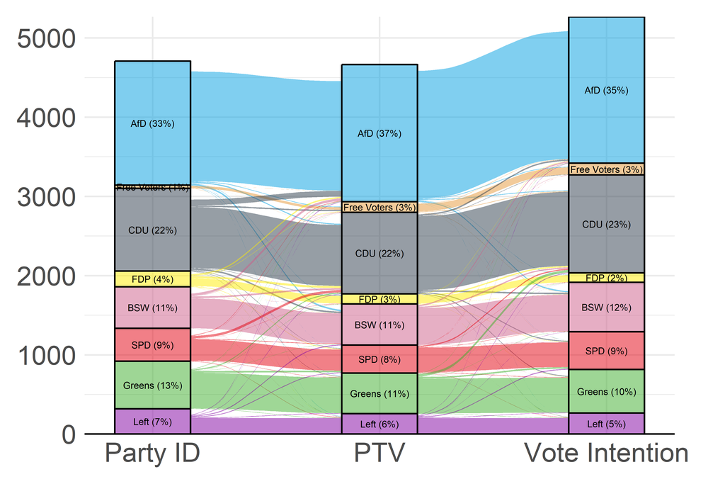

```r
party_order_saxony <- c("AfD", "Free Voters", "CDU", "FDP", "BSW", "SPD", "Greens", "Left")

plot_alluvial_saxony <- plot_pref_flow(pref_measures_saxony, party_order_saxony) # helper
plot_alluvial_saxony
```

```r
save_figure(plot_alluvial_saxony, "figure_B4_desc_pref_comparison_saxony",
  election = "saxony", # helper
  width = "landscape", aspect = 6 / 10
)
```

# Response Times (Figures B.1, B.2)

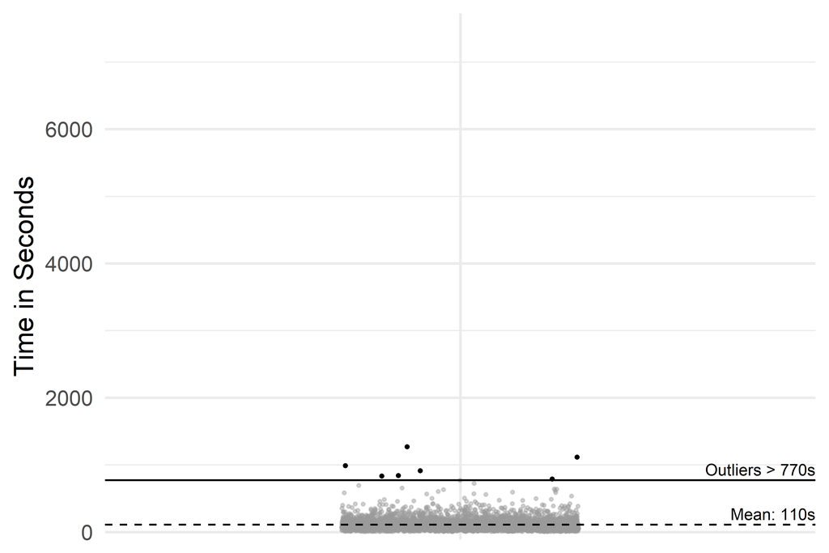

```r
plot_response_times_outliers_saxony <- plot_time_outliers(data_saxony_time_main, t_mean_saxony, t_threshold_upper_saxony) # helper
plot_response_times_outliers_saxony
```

```r
save_figure(plot_response_times_outliers_saxony, "figure_B1b_desc_time_dist_saxony",
  election = "saxony", # helper
  width = "subfigure", aspect = 6 / 8
)
```

Response times in seconds and logged (dependent variable of H1), without outliers.

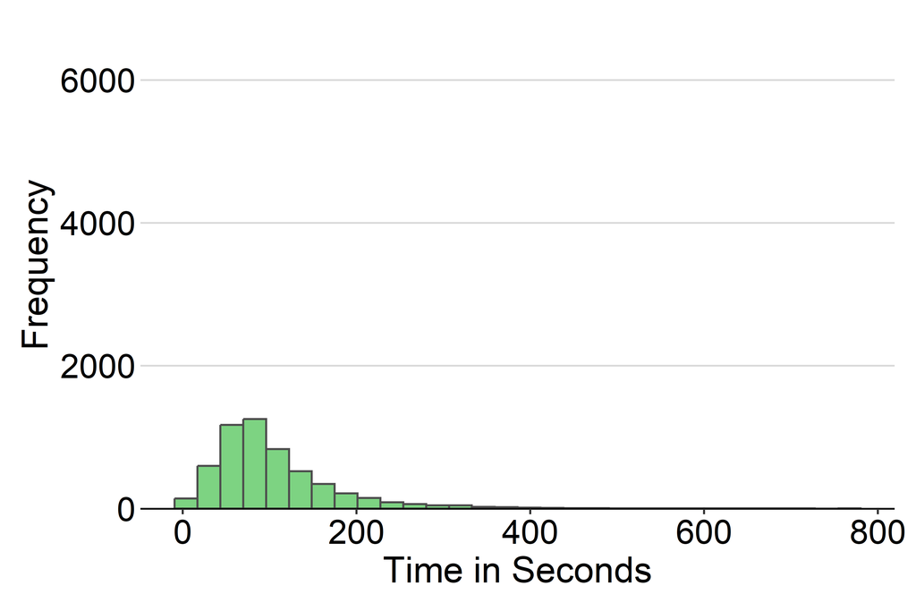

```r
plot_response_times_s_saxony <- plot_time_hist(data_saxony_time_main_nooutliers, "t_list_votes_exp_Page_Submit", # helper
  "Time in Seconds",
  election = "saxony"
)
plot_response_times_log_saxony <- plot_time_hist(data_saxony_time_main_nooutliers, "t_list_votes_exp_Page_Submit_log", # helper
  "log(seconds)",
  election = "saxony"
)
plot_response_times_s_saxony
```

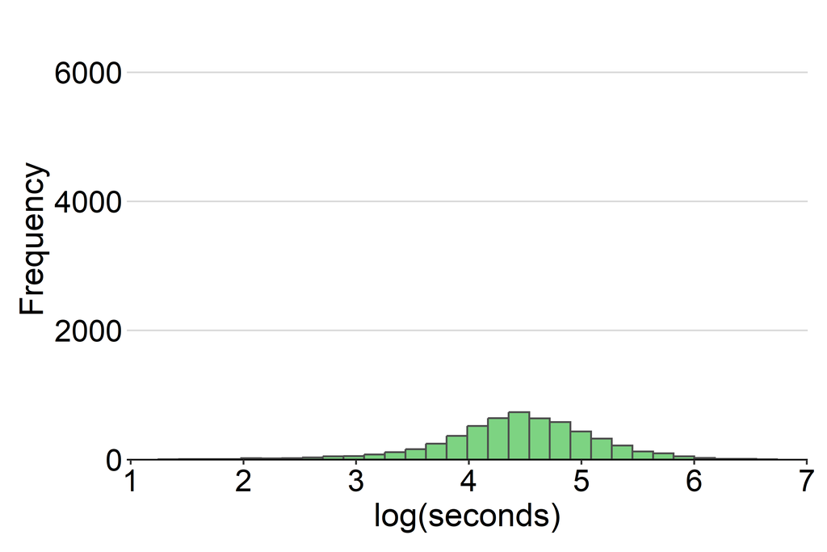

```r
plot_response_times_log_saxony
```

```r
save_figure(plot_response_times_s_saxony, "figure_B2c_desc_time_hist_saxony",
  election = "saxony", # helper
  width = "subfigure", aspect = 6 / 8
)
save_figure(plot_response_times_log_saxony, "figure_B2d_desc_time_loghist_saxony",
  election = "saxony", # helper
  width = "subfigure", aspect = 6 / 8
)
```

# Vote Share Expectations (Figure 1, Table B.6)

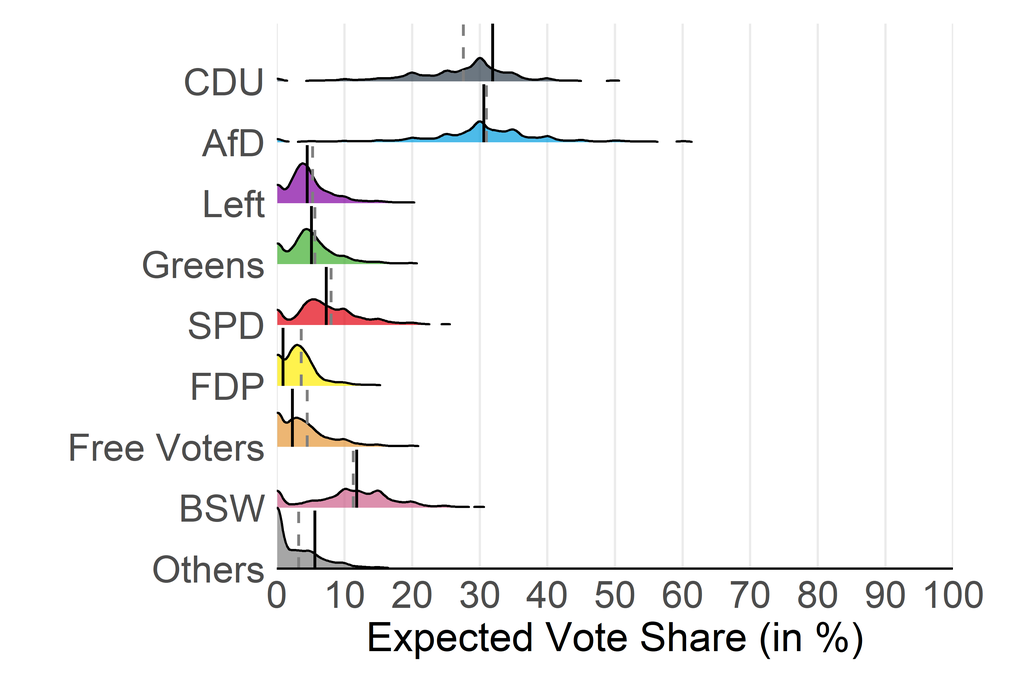

```r
plot_voteshare_dist_saxony <- plot_vote_share_dist(data_saxony_long_main, election = "saxony") # helper
save_figure(plot_voteshare_dist_saxony, "figure_1b_desc_voteshare_dist_saxony",
  election = "saxony", # helper
  width = "half", aspect = 8 / 12
)
plot_voteshare_dist_saxony
```

Spread of the individual expectations per party (paper section Data).

```r
data_saxony_long_main %>%
  group_by(party) %>%
  summarize(result = first(list_votes_result), mean = mean(list_votes_exp), sd = sd(list_votes_exp)) %>%
  arrange(sd) %>%
  print_values(digits = 2) # helper
```

```
       party result  mean    sd
         FDP   0.89  3.57  4.19
      Others   5.58  3.20  4.58
 Free Voters   2.26  4.46  5.30
        Left   4.47  5.28  5.55
      Greens   5.11  5.59  5.68
         SPD   7.33  8.02  6.67
         BSW  11.82 11.28  7.45
         CDU  31.90 27.56 10.54
         AfD  30.63 31.04 12.45
```

Mean, deviation from the result and SD per party, overall and by group.

```r
accuracy_input_saxony <- data_saxony_long_main %>% mutate(party = recode_party_names_saxony(party)) # helper

accuracy_table_data_saxony <- compute_accuracy_by_group(accuracy_input_saxony, "all", election = "saxony") %>% # helper
  left_join(compute_accuracy_by_group(filter(accuracy_input_saxony, treatment == "Control"), "c", election = "saxony"), # helper
    by = c("party", "list_votes_result")
  ) %>%
  left_join(compute_accuracy_by_group(filter(accuracy_input_saxony, treatment == "Treatment (500)"), "t500", election = "saxony"), # helper
    by = c("party", "list_votes_result")
  ) %>%
  arrange(party)

write_accuracy_table( # helper
  accuracy_table_data_saxony,
  groups  = c(all = "Full Sample", c = "Control", t500 = "Treatment (500)"),
  caption = "Forecasting Accuracy by Party and Treatment Group (Saxony)",
  label   = "tab:accuracy_saxony",
  note    = note_accuracy,
  file    = "output/tables/table_B6_accuracy_saxony.tex"
)
```

Forecasting Accuracy by Party and Treatment Group (Saxony)

| Party | Result | Full Sample Mean | Full Sample Dev.<sup>1</sup> | Full Sample SD | Control Avg. | Control Dev. | Control SD | Treatment (500) Avg. | Treatment (500) Dev. | Treatment (500) SD |
| --- | --- | --- | --- | --- | --- | --- | --- | --- | --- | --- |
| AfD | 30.63 | 31.04 | 0.41 | 12.45 | 31.14 | 0.50 | 12.88 | 30.94 | 0.31 | 11.99 |
| BSW | 11.82 | 11.28 | −0.54 | 7.45 | 11.23 | −0.59 | 7.82 | 11.33 | −0.49 | 7.04 |
| CDU | 31.90 | 27.56 | −4.34 | 10.54 | 27.91 | −4.00 | 11.06 | 27.21 | −4.70 | 9.97 |
| FDP | 0.89 | 3.57 | 2.67 | 4.19 | 3.56 | 2.66 | 4.62 | 3.58 | 2.69 | 3.70 |
| Greens | 5.11 | 5.59 | 0.48 | 5.68 | 5.60 | 0.49 | 6.23 | 5.57 | 0.46 | 5.04 |
| Left | 4.47 | 5.28 | 0.82 | 5.55 | 5.20 | 0.73 | 5.64 | 5.37 | 0.90 | 5.45 |
| SPD | 7.33 | 8.02 | 0.69 | 6.67 | 7.90 | 0.58 | 6.73 | 8.13 | 0.80 | 6.61 |
| Free Voters | 2.26 | 4.46 | 2.20 | 5.30 | 4.33 | 2.07 | 5.24 | 4.60 | 2.34 | 5.36 |
| Others | 5.58 | 3.20 | −2.39 | 4.58 | 3.13 | −2.46 | 4.77 | 3.27 | −2.31 | 4.38 |
| MAE |  |  | 1.62 |  |  | 1.57 |  |  | 1.67 |  |
| RMSE |  |  | 2.07 |  |  | 1.98 |  |  | 2.16 |  |

<sup>1</sup> Dev. = Mean - Result. The mean of the individual expectations equals the citizen forecast. The 'MAE' / 'RMSE' rows give the accuracy of these group-level vote share forecasts.

# Forecast Error for the Preferred Party (Figure B.6)

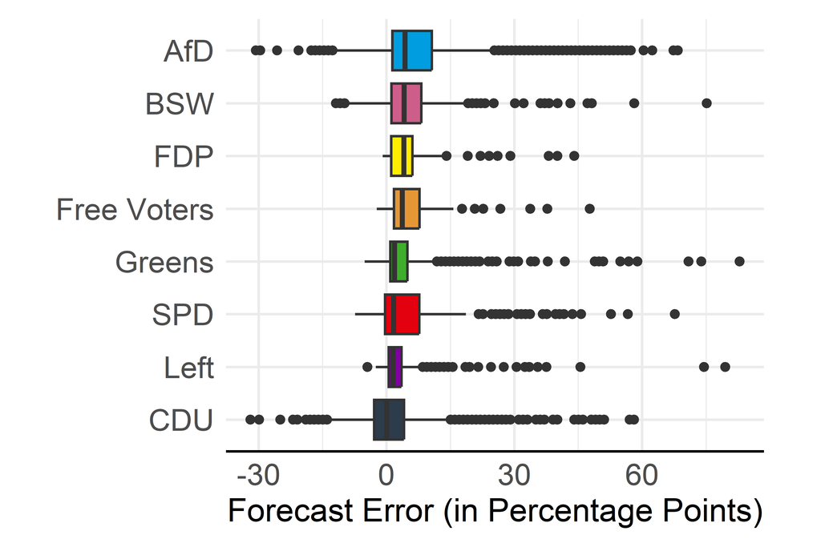

```r
plot_pref_boxplot_saxony <- plot_pref_boxplot(data_saxony_prefparty_ptv_main) # helper
plot_pref_boxplot_saxony
```

```r
save_figure(plot_pref_boxplot_saxony, "figure_B6_desc_pref_boxplot_ptv_saxony",
  election = "saxony", # helper
  width = "boxplot", aspect = 6 / 8
)
```

Note of Figure B.6: preferred parties, share underestimating them, and observed and possible range of the forecast error (sliders from 0 to 100).

```r
data_saxony_prefparty_ptv_main %>%
  group_by(party) %>%
  summarize(
    n = n(), pct_underestimated = 100 * mean(list_votes_exp_diff < 0),
    observed_min = min(list_votes_exp_diff), observed_max = max(list_votes_exp_diff),
    possible_min = -first(list_votes_result), possible_max = 100 - first(list_votes_result),
    .groups = "drop"
  ) %>%
  mutate(pct_respondents = 100 * n / sum(n)) %>%
  arrange(desc(n)) %>%
  print_values(digits = 1) # helper
```

```
       party    n pct_underestimated observed_min observed_max possible_min possible_max pct_respondents
         AfD 1732               17.6        -30.6         68.4        -30.6         69.4            37.1
         CDU 1028               44.7        -31.9         58.1        -31.9         68.1            22.0
         BSW  519               19.3        -11.8         75.2        -11.8         88.2            11.1
      Greens  514               20.4         -5.1         82.9         -5.1         94.9            11.0
         SPD  352               33.2         -7.3         67.7         -7.3         92.7             7.5
        Left  257               21.8         -4.5         79.5         -4.5         95.5             5.5
 Free Voters  134               15.7         -2.3         47.7         -2.3         97.7             2.9
         FDP  129               15.5         -0.9         44.1         -0.9         99.1             2.8
```

Share underestimating the preferred party, overall (%).

```r
data_saxony_prefparty_ptv_main %>%
  summarize(pct_underestimated = 100 * mean(list_votes_exp_diff < 0))
```

```
# A tibble: 1 × 1
  pct_underestimated
               <dbl>
1               25.4
```

Highest PTV score of the preferred party.

```r
data_saxony_ptv_main %>%
  filter(preferred_party_ptv_dummy == 1) %>%
  count(ptv_score) %>%
  mutate(pct = 100 * n / sum(n)) %>%
  arrange(desc(ptv_score)) %>%
  print_values(digits = 2) # helper
```

```
 ptv_score    n   pct
        11 2935 62.92
        10  848 18.18
         9  462  9.90
         8  253  5.42
         7   79  1.69
         6   41  0.88
         5   27  0.58
         4    7  0.15
         3    7  0.15
         2    5  0.11
         1    1  0.02
```

# Save for the Analysis

The analysis data sets are saved to `data/processed/`.

```r
save(data_saxony_main,                 file = "data/processed/data_saxony_main.rdata")
save(data_saxony_noexcl,               file = "data/processed/data_saxony_noexcl.rdata")
save(data_saxony_time_main_nooutliers, file = "data/processed/data_saxony_time_main_nooutliers.rdata")
save(data_saxony_time_noexcl,          file = "data/processed/data_saxony_time_noexcl.rdata")
save(data_saxony_ptv_main,             file = "data/processed/data_saxony_ptv_main.rdata")
save(data_saxony_ptv_noexcl,           file = "data/processed/data_saxony_ptv_noexcl.rdata")
save(data_saxony_ptvties_main,         file = "data/processed/data_saxony_ptvties_main.rdata")
save(data_saxony_ptvties_noexcl,       file = "data/processed/data_saxony_ptvties_noexcl.rdata")
save(data_saxony_ptvscore_main,        file = "data/processed/data_saxony_ptvscore_main.rdata")
save(data_saxony_ptvscore_noexcl,      file = "data/processed/data_saxony_ptvscore_noexcl.rdata")
save(data_saxony_vi_main,              file = "data/processed/data_saxony_vi_main.rdata")
save(data_saxony_vi_noexcl,            file = "data/processed/data_saxony_vi_noexcl.rdata")
save(data_saxony_pid_main,             file = "data/processed/data_saxony_pid_main.rdata")
save(data_saxony_pid_noexcl,           file = "data/processed/data_saxony_pid_noexcl.rdata")
```